# Inferência Estatística - Exemplo eleição

Marcus Carvalho (adaptado de Nazareno Andrade e Raquel Lopes)

Análise de Dados I - 2018.1

Neste exemplo, nós vamos mostrar como inferir o resultado de uma eleição (população) com base em pesquisas eleitorais (amostras). A ideia é analisar as diferentes conclusões que podem ser chegadas através da amostragem e mostrar que o objetivo da inferência é indicar a margem de erro das estimativas.

Este exemplo serve como motivação para o uso de métodos de inferência estatística.

# Simulando votos em uma eleição presidencial

Inicialmente, iremos simular uma eleição com 100 milhões de eleitores, onde os candidatos a presidente receberam as seguintes porcentagens de votos: Lula 37%, Bolsonaro 19%, Marina 16%, Ciro 15% e Alckmin 13%.

Também serão simuladas 100 pesquisas eleitorais, onde em cada pesquisa foram consultados 2000 eleitores. Cada pesquisa será uma amostra, que será gerada com o comando `sample` usando as porcentagens de voto da eleição “real” (população) mostrada acima para gerar opiniões de votos aleatórios nas pesquisas.

Abaixo podemos visualizar como exemplo o resultado da primeira pesquisa. Note que a porcentagem de votos não é exatamente igual ao da população total de 100 milhões de eleitores, por se tratar apenas de uma amostra de 2000 pesquisados.

| candidato_votado | n_votos_pesquisa | porcentagem_votos_pesquisa |
| --- | --- | --- |
| Lula | 775 | 38.8% |
| Bolsonaro | 361 | 18% |
| Marina | 315 | 15.8% |
| Ciro | 308 | 15.4% |
| Alckmin | 241 | 12% |

Outras pesquisas podem gerar porcentagens diferentes, podendo em alguns casos alterar a ordem dos candidatos mais votados.

| id_pesquisa | candidato_votado | n_votos_pesquisa | porcentagem_votos_pesquisa |
| --- | --- | --- | --- |
| 1 | Lula | 775 | 0.3875 |
| 1 | Bolsonaro | 361 | 0.1805 |
| 1 | Marina | 315 | 0.1575 |
| 1 | Ciro | 308 | 0.1540 |
| 1 | Alckmin | 241 | 0.1205 |
| 2 | Lula | 760 | 0.3800 |
| 2 | Bolsonaro | 341 | 0.1705 |
| 2 | Marina | 315 | 0.1575 |
| 2 | Ciro | 324 | 0.1620 |
| 2 | Alckmin | 260 | 0.1300 |

[output cut: 490 more lines]

Vamos olhar graficamente como foram os resultados das 100 pesquisas eleitorais realizadas. Cada círculo representa a porcentagem de votos de um candidato em uma pesquisa eleitoral. A barra de erro mostra o 2,5-percentil e o 97,5-percentil da porcentagem de votos para cada candidato, ou seja, em 95% das pesquisas a porcentagem de votos de um candidato ficou dentro dos limites da barra de erro. A largura desta barra dá um indicativo da margem de erro do resultado das amostras.

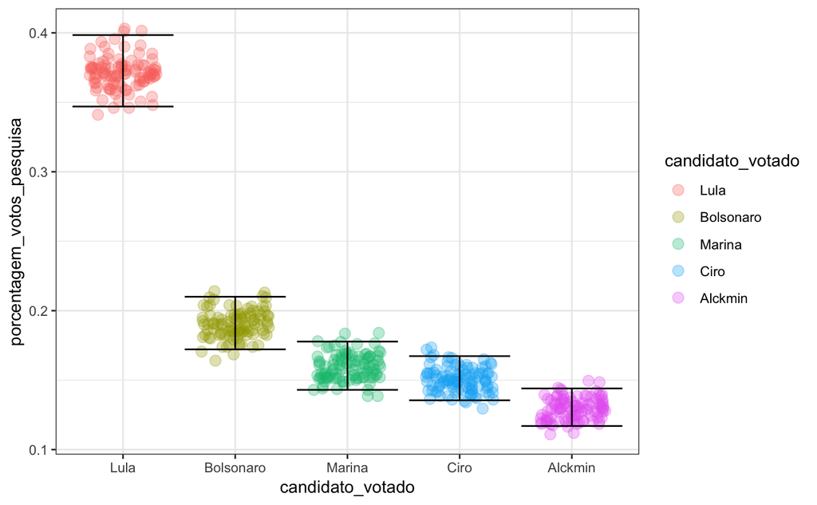

Qual é o impacto do tamanho da amostra na margem de erro? A proporção de votos de um candidato também impacta na sua margem de erro?

A margem de erro para uma proporção é calculado da seguinte forma:

$$\varepsilon = z . \sqrt{\frac{p (1 - p)}{n}}$$

onde $p$ é o valor da proporção, $n$ é o tamanho da amostra e $z$ é o valor da distribuição normal correspondente ao nível de confianç desejado (ex: $z = 1,96$ para um nível de confiança de 95%).

Com base na margem de erro da proporção, podemos visualizar o impacto do tamanho da amostra $n$ e da proporção $p$ na margem de erro $\varepsilon$:

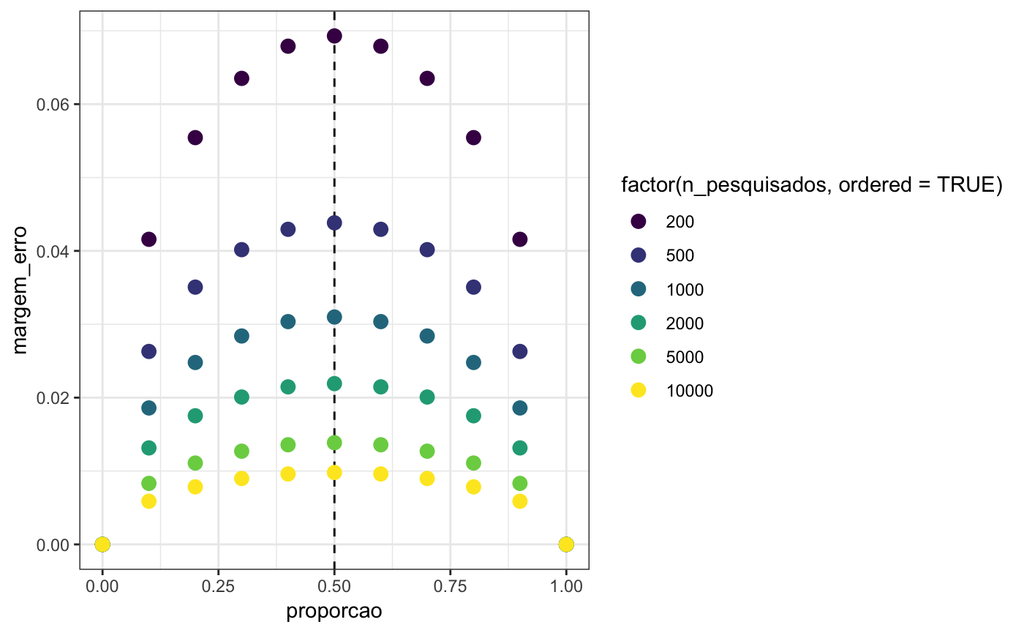

Podemos observar que a margem de erro máxima ocorre quanto o valor da proporção é igual a 0,5. Na prática, as pesquisas eleitorais trabalham com a margem de erro máxima, considerando o valor 0,5 ao indicar a margem de erro.

Fixando a proporção em 0,5 podemos então analisar a margem de erro máxima para diferentes tamanhos de amostra:

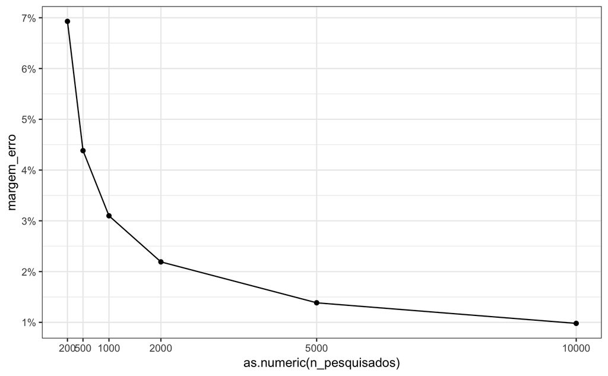